# Part I - Prosper Loan Data

## Introduction

This data set contains 113,937 loans with 81 variables on each loan, including loan amount, borrower rate (or interest rate), current loan status, borrower income, and many others.

- ListingKey Unique key for each listing, same value as the 'key' used in the listing object in the API.
- ListingNumber The number that uniquely identifies the listing to the public as displayed on the website.
- ListingCreationDate The date the listing was created.
- CreditGrade The Credit rating that was assigned at the time the listing went live. Applicable for listings pre-2009 period and will only be populated for those listings.
- Term The length of the loan expressed in months.
- LoanStatus The current status of the loan: Cancelled, Chargedoff, Completed, Current, Defaulted, FinalPaymentInProgress, PastDue. The PastDue status will be accompanied by a delinquency bucket.
- ClosedDate Closed date is applicable for Cancelled, Completed, Chargedoff and Defaulted loan statuses.
- BorrowerAPR The Borrower's Annual Percentage Rate (APR) for the loan.
- BorrowerRate The Borrower's interest rate for this loan.
- LenderYield The Lender yield on the loan. Lender yield is equal to the interest rate on the loan less the servicing fee.
- EstimatedEffectiveYield Effective yield is equal to the borrower interest rate (i) minus the servicing fee rate, (ii) minus estimated uncollected interest on charge-offs, (iii) plus estimated collected late fees. Applicable for loans originated after July 2009.
- EstimatedLoss Estimated loss is the estimated principal loss on charge-offs. Applicable for loans originated after July 2009.
- EstimatedReturn The estimated return assigned to the listing at the time it was created. Estimated return is the difference between the Estimated Effective Yield and the Estimated Loss Rate. Applicable for loans originated after July 2009.
- ProsperRating (numeric) The Prosper Rating assigned at the time the listing was created: 0 - N/A, 1 - HR, 2 - E, 3 - D, 4 - C, 5 - B, 6 - A, 7 - AA. Applicable for loans originated after July 2009.
- ProsperRating (Alpha) The Prosper Rating assigned at the time the listing was created between AA - HR. Applicable for loans originated after July 2009.
- ProsperScore A custom risk score built using historical Prosper data. The score ranges from 1-10, with 10 being the best, or lowest risk score. Applicable for loans originated after July 2009.
- ListingCategory The category of the listing that the borrower selected when posting their listing: 0 - Not Available, 1 - Debt Consolidation, 2 - Home Improvement, 3 - Business, 4 - Personal Loan, 5 - Student Use, 6 - Auto, 7- Other, 8 - Baby&Adoption, 9 - Boat, 10 - Cosmetic Procedure, 11 - Engagement Ring, 12 - Green Loans, 13 - Household Expenses, 14 - Large Purchases, 15 - Medical/Dental, 16 - Motorcycle, 17 - RV, 18 - Taxes, 19 - Vacation, 20 - Wedding Loans
- BorrowerState The two letter abbreviation of the state of the address of the borrower at the time the Listing was created.
- Occupation The Occupation selected by the Borrower at the time they created the listing.
- EmploymentStatus The employment status of the borrower at the time they posted the listing.
- EmploymentStatusDuration The length in months of the employment status at the time the listing was created.
- IsBorrowerHomeowner A Borrower will be classified as a homowner if they have a mortgage on their credit profile or provide documentation confirming they are a homeowner.
- CurrentlyInGroup Specifies whether or not the Borrower was in a group at the time the listing was created.
- GroupKey The Key of the group in which the Borrower is a member of. Value will be null if the borrower does not have a group affiliation.
- DateCreditPulled The date the credit profile was pulled.
- CreditScoreRangeLower The lower value representing the range of the borrower's credit score as provided by a consumer credit rating agency.
- CreditScoreRangeUpper The upper value representing the range of the borrower's credit score as provided by a consumer credit rating agency.
- FirstRecordedCreditLine The date the first credit line was opened.
- CurrentCreditLines Number of current credit lines at the time the credit profile was pulled.
- OpenCreditLines Number of open credit lines at the time the credit profile was pulled.
- TotalCreditLinespast7years Number of credit lines in the past seven years at the time the credit profile was pulled.
- OpenRevolvingAccounts Number of open revolving accounts at the time the credit profile was pulled.
- OpenRevolvingMonthlyPayment Monthly payment on revolving accounts at the time the credit profile was pulled.
- InquiriesLast6Months Number of inquiries in the past six months at the time the credit profile was pulled.
- TotalInquiries Total number of inquiries at the time the credit profile was pulled.
- CurrentDelinquencies Number of accounts delinquent at the time the credit profile was pulled.
- AmountDelinquent Dollars delinquent at the time the credit profile was pulled.
- DelinquenciesLast7Years Number of delinquencies in the past 7 years at the time the credit profile was pulled.
- PublicRecordsLast10Years Number of public records in the past 10 years at the time the credit profile was pulled.
- PublicRecordsLast12Months Number of public records in the past 12 months at the time the credit profile was pulled.
- RevolvingCreditBalance Dollars of revolving credit at the time the credit profile was pulled.
- BankcardUtilization The percentage of available revolving credit that is utilized at the time the credit profile was pulled.
- AvailableBankcardCredit The total available credit via bank card at the time the credit profile was pulled.
- TotalTrades Number of trade lines ever opened at the time the credit profile was pulled.
- TradesNeverDelinquent Number of trades that have never been delinquent at the time the credit profile was pulled.
- TradesOpenedLast6Months Number of trades opened in the last 6 months at the time the credit profile was pulled.
- DebtToIncomeRatio The debt to income ratio of the borrower at the time the credit profile was pulled. This value is Null if the debt to income ratio is not available. This value is capped at 10.01 (any debt to income ratio larger than 1000% will be returned as 1001%).
- IncomeRange The income range of the borrower at the time the listing was created.
- IncomeVerifiable The borrower indicated they have the required documentation to support their income.
- StatedMonthlyIncome The monthly income the borrower stated at the time the listing was created.
- LoanKey Unique key for each loan. This is the same key that is used in the API.
- TotalProsperLoans Number of Prosper loans the borrower at the time they created this listing. This value will be null if the borrower had no prior loans.
- TotalProsperPaymentsBilled Number of on time payments the borrower made on Prosper loans at the time they created this listing. This value will be null if the borrower had no prior loans.
- OnTimeProsperPayments Number of on time payments the borrower had made on Prosper loans at the time they created this listing. This value will be null if the borrower has no prior loans.
- ProsperPaymentsLessThanOneMonthLate Number of payments the borrower made on Prosper loans that were less than one month late at the time they created this listing. This value will be null if the borrower had no prior loans.
- ProsperPaymentsOneMonthPlusLate Number of payments the borrower made on Prosper loans that were greater than one month late at the time they created this listing. This value will be null if the borrower had no prior loans.
- ProsperPrincipalBorrowed Total principal borrowed on Prosper loans at the time the listing was created. This value will be null if the borrower had no prior loans.
- ProsperPrincipalOutstanding Principal outstanding on Prosper loans at the time the listing was created. This value will be null if the borrower had no prior loans.
- ScorexChangeAtTimeOfListing Borrower's credit score change at the time the credit profile was pulled. This will be the change relative to the borrower's last Prosper loan. This value will be null if the borrower had no prior loans.
- LoanCurrentDaysDelinquent The number of days delinquent.
- LoanFirstDefaultedCycleNumber The cycle the loan was charged off. If the loan has not charged off the value will be null.
- LoanMonthsSinceOrigination Number of months since the loan originated.
- LoanNumber Unique numeric value associated with the loan.
- LoanOriginalAmount The origination amount of the loan.
- LoanOriginationDate The date the loan was originated.
- LoanOriginationQuarter The quarter in which the loan was originated.
- MemberKey The unique key that is associated with the borrower. This is the same identifier that is used in the API member object.
- MonthlyLoanPayment The scheduled monthly loan payment.
- LP_CustomerPayments Pre charge-off cumulative gross payments made by the borrower on the loan. If the loan has charged off, this value will exclude any recoveries.
- LP_CustomerPrincipalPayments Pre charge-off cumulative principal payments made by the borrower on the loan. If the loan has charged off, this value will exclude any recoveries.
- LP_InterestandFees Pre charge-off cumulative interest and fees paid by the borrower. If the loan has charged off, this value will exclude any recoveries.
- LP_ServiceFees Cumulative service fees paid by the investors who have invested in the loan.
- LP_CollectionFees Cumulative collection fees paid by the investors who have invested in the loan.
- LP_GrossPrincipalLoss The gross charged off amount of the loan.
- LP_NetPrincipalLoss The principal that remains uncollected after any recoveries.
- LP_NonPrincipalRecoverypayments The interest and fee component of any recovery payments. The current payment policy applies payments in the following order: Fees, interest, principal.
- PercentFunded Percent the listing was funded.
- Recommendations Number of recommendations the borrower had at the time the listing was created.
- InvestmentFromFriendsCount Number of friends that made an investment in the loan.
- InvestmentFromFriendsAmount Dollar amount of investments that were made by friends.
- Investors The number of investors that funded the loan.

## Preliminary Wrangling

```python
# import all packages and set plots to be embedded inline
import numpy as np
import pandas as pd
import matplotlib.pyplot as plt
import seaborn as sns

%matplotlib inline
```

```python
# Loading the dataset
df = pd.read_csv("prosperLoanData.csv")
df.head(2)
```

|  | ListingKey | ListingNumber | ListingCreationDate | CreditGrade | Term | LoanStatus | ClosedDate | BorrowerAPR | BorrowerRate | LenderYield | ... | LP_ServiceFees | LP_CollectionFees | LP_GrossPrincipalLoss | LP_NetPrincipalLoss | LP_NonPrincipalRecoverypayments | PercentFunded | Recommendations | InvestmentFromFriendsCount | InvestmentFromFriendsAmount | Investors |
| --- | --- | --- | --- | --- | --- | --- | --- | --- | --- | --- | --- | --- | --- | --- | --- | --- | --- | --- | --- | --- | --- |
| 0 | 1021339766868145413AB3B | 193129 | 2007-08-26 19:09:29.263000000 | C | 36 | Completed | 2009-08-14 00:00:00 | 0.16516 | 0.158 | 0.138 | ... | -133.18 | 0.0 | 0.0 | 0.0 | 0.0 | 1.0 | 0 | 0 | 0.0 | 258 |
| 1 | 10273602499503308B223C1 | 1209647 | 2014-02-27 08:28:07.900000000 | NaN | 36 | Current | NaN | 0.12016 | 0.092 | 0.082 | ... | 0.00 | 0.0 | 0.0 | 0.0 | 0.0 | 1.0 | 0 | 0 | 0.0 | 1 |

2 rows × 81 columns

### What is the structure of your dataset?

The data has 113937 loan records and 81 columns or attribute

### What is/are the main feature(s) of interest in your dataset?

**LoanStatus**

This is the current status of the loan: It could be

- Cancelled,
- Chargedoff,
- Completed,
- Current,
- Defaulted,
- FinalPaymentInProgress,
- PastDue.

### What features in the dataset do you think will help support your investigation into your feature(s) of interest?

- ListingKey Unique key for each listing, same value as the 'key' used in the listing object in the API.
- ListingNumber The number that uniquely identifies the listing to the public as displayed on the website.
- ListingCreationDate The date the listing was created.
- CreditGrade The Credit rating that was assigned at the time the listing went live. Applicable for listings pre-2009 period and will only be populated for those listings.
- Term The length of the loan expressed in months.
- LoanStatus The current status of the loan: Cancelled, Chargedoff, Completed, Current, Defaulted, FinalPaymentInProgress, PastDue. The PastDue status will be accompanied by a delinquency bucket.
- ClosedDate Closed date is applicable for Cancelled, Completed, Chargedoff and Defaulted loan statuses.
- BorrowerAPR The Borrower's Annual Percentage Rate (APR) for the loan.
- BorrowerRate The Borrower's interest rate for this loan.
- LenderYield The Lender yield on the loan. Lender yield is equal to the interest rate on the loan less the servicing fee.
- EstimatedEffectiveYield Effective yield is equal to the borrower interest rate (i) minus the servicing fee rate, (ii) minus estimated uncollected interest on charge-offs, (iii) plus estimated collected late fees. Applicable for loans originated after July 2009.
- EstimatedLoss Estimated loss is the estimated principal loss on charge-offs. Applicable for loans originated after July 2009.
- EstimatedReturn The estimated return assigned to the listing at the time it was created. Estimated return is the difference between the Estimated Effective Yield and the Estimated Loss Rate. Applicable for loans originated after July 2009.
- ProsperRating (numeric) The Prosper Rating assigned at the time the listing was created: 0 - N/A, 1 - HR, 2 - E, 3 - D, 4 - C, 5 - B, 6 - A, 7 - AA. Applicable for loans originated after July 2009.
- ProsperRating (Alpha) The Prosper Rating assigned at the time the listing was created between AA - HR. Applicable for loans originated after July 2009.
- ProsperScore A custom risk score built using historical Prosper data. The score ranges from 1-10, with 10 being the best, or lowest risk score. Applicable for loans originated after July 2009.
- ListingCategory The category of the listing that the borrower selected when posting their listing: 0 - Not Available, 1 - Debt Consolidation, 2 - Home Improvement, 3 - Business, 4 - Personal Loan, 5 - Student Use, 6 - Auto, 7- Other, 8 - Baby&Adoption, 9 - Boat, 10 - Cosmetic Procedure, 11 - Engagement Ring, 12 - Green Loans, 13 - Household Expenses, 14 - Large Purchases, 15 - Medical/Dental, 16 - Motorcycle, 17 - RV, 18 - Taxes, 19 - Vacation, 20 - Wedding Loans
- BorrowerState The two letter abbreviation of the state of the address of the borrower at the time the Listing was created.
- Occupation The Occupation selected by the Borrower at the time they created the listing.
- EmploymentStatus The employment status of the borrower at the time they posted the listing.
- EmploymentStatusDuration The length in months of the employment status at the time the listing was created.
- IsBorrowerHomeowner A Borrower will be classified as a homowner if they have a mortgage on their credit profile or provide documentation confirming they are a homeowner.
- CurrentlyInGroup Specifies whether or not the Borrower was in a group at the time the listing was created.
- GroupKey The Key of the group in which the Borrower is a member of. Value will be null if the borrower does not have a group affiliation.
- DateCreditPulled The date the credit profile was pulled.
- CreditScoreRangeLower The lower value representing the range of the borrower's credit score as provided by a consumer credit rating agency.
- CreditScoreRangeUpper The upper value representing the range of the borrower's credit score as provided by a consumer credit rating agency.
- DebtToIncomeRatio The debt to income ratio of the borrower at the time the credit profile was pulled. This value is Null if the debt to income ratio is not available. This value is capped at 10.01 (any debt to income ratio larger than 1000% will be returned as 1001%).
- IncomeRange The income range of the borrower at the time the listing was created.
- IncomeVerifiable The borrower indicated they have the required documentation to support their income.
- StatedMonthlyIncome The monthly income the borrower stated at the time the listing was created.
- LoanKey Unique key for each loan. This is the same key that is used in the API.
- TotalProsperLoans Number of Prosper loans the borrower at the time they created this listing. This value will be null if the borrower had no prior loans.
- TotalProsperPaymentsBilled Number of on time payments the borrower made on Prosper loans at the time they created this listing. This value will be null if the borrower had no prior loans.
- OnTimeProsperPayments Number of on time payments the borrower had made on Prosper loans at the time they created this listing. This value will be null if the borrower has no prior loans.
- ProsperPaymentsLessThanOneMonthLate Number of payments the borrower made on Prosper loans that were less than one month late at the time they created this listing. This value will be null if the borrower had no prior loans.
- ProsperPaymentsOneMonthPlusLate Number of payments the borrower made on Prosper loans that were greater than one month late at the time they created this listing. This value will be null if the borrower had no prior loans.
- ProsperPrincipalBorrowed Total principal borrowed on Prosper loans at the time the listing was created. This value will be null if the borrower had no prior loans.
- ProsperPrincipalOutstanding Principal outstanding on Prosper loans at the time the listing was created. This value will be null if the borrower had no prior loans.
- ScorexChangeAtTimeOfListing Borrower's credit score change at the time the credit profile was pulled. This will be the change relative to the borrower's last Prosper loan. This value will be null if the borrower had no prior loans.
- LoanCurrentDaysDelinquent The number of days delinquent.
- LoanFirstDefaultedCycleNumber The cycle the loan was charged off. If the loan has not charged off the value will be null.
- LoanMonthsSinceOrigination Number of months since the loan originated.
- LoanNumber Unique numeric value associated with the loan.
- LoanOriginalAmount The origination amount of the loan.
- LoanOriginationDate The date the loan was originated.
- LoanOriginationQuarter The quarter in which the loan was originated.
- MemberKey The unique key that is associated with the borrower. This is the same identifier that is used in the API member object.
- MonthlyLoanPayment The scheduled monthly loan payment.
- LP_CustomerPayments Pre charge-off cumulative gross payments made by the borrower on the loan. If the loan has charged off, this value will exclude any recoveries.
- LP_CustomerPrincipalPayments Pre charge-off cumulative principal payments made by the borrower on the loan. If the loan has charged off, this value will exclude any recoveries.

## Univariate Exploration

### How many records are there for each loan status?

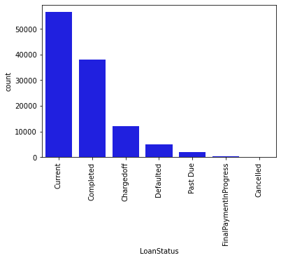

```python
# Creating a dictionary that maps past due loans irrespective of the number of days, into "Past Due"
past_due = {"Current"  : "Current",
"Completed": "Completed",
"Chargedoff": "Chargedoff",
"Defaulted": "Defaulted",
"Past Due (1-15 days)": "Past Due",
"Past Due (31-60 days)": "Past Due",
"Past Due (61-90 days)"  :"Past Due",
"Past Due (91-120 days)":  "Past Due",
"Past Due (16-30 days)": "Past Due",
"FinalPaymentInProgress":"FinalPaymentInProgress",
"Past Due (>120 days)":"Past Due",
"Cancelled":"Cancelled"}

# Changing all past due loans irrespective of the number of days, into "Past Due"
df.LoanStatus = df.LoanStatus.map(past_due)

# making a plot of the Loan status and the number of times they occur
sns.countplot(data = df, x="LoanStatus", color ="blue", order=list(df.LoanStatus.value_counts().index))
plt.xticks(rotation=90)
plt.show()
plt.clf()
```

Majority(49.65%) of the loans are current, 33.42% of the loans are completed, 10.53% and 4.40% are chargedoff and defaulted respectively with 1.81% percent past due

### How is term of the loan distributed?

```python
Term = {12: "1 Year",
       36: "3 Years",
       60: "5 Years"}

# Coverting the months into years by mapping the number of months to their appropriate Year
df.Term = df.Term.map(Term)
```

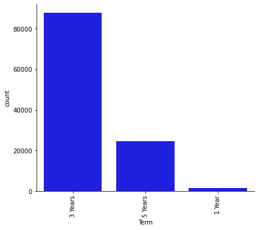

```python
# making a plot of the Lona Term and the number of times they occur
sns.catplot(data = df, x="Term",kind="count", color ="blue",aspect = 1.2, order=list(df["Term"].value_counts().index))
plt.xticks(rotation=90)
plt.show()
plt.clf()
```

77.04% of the loans have a term of 36 months, 21.54% have a term of 60 months with only 1.42% having a term of 12 months

### How is BorrowerRate of the loan distributed?

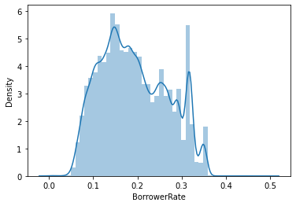

```python
# making a plot that shows the distribution of The Borrower rate of the loans
sns.distplot(df["BorrowerRate"])
plt.show()
```

### Which categories had more loan listings

```python
ListingCategory = {0 : "Not Available",
                   1 : "Debt Consolidation",
                   2 : "Home Improvement",
                   3 : "Business",
                   4 : "Personal Loan",
                   5 : "Student Use",
                   6 : "Auto",
                   7 : "Other",
                   8 : "Baby&Adoption",
                   9 : "Boat",
                   10 : "Cosmetic Procedure",
                   11 : "Engagement Ring",
                   12 : "Green Loans",
                   13 : "Household Expenses",
                   14 : "Large Purchases",
                   15 : "Medical/Dental",
                   16 : "Motorcycle",
                   17 : "RV",
                   18 : "Taxes",
                   19 : "Vacation",
                   20 : "Wedding Loans"}

# Creating a columns that conatins the listing category form the 'ListingCategory (numeric)' column
df["ListingCategory"] = df['ListingCategory (numeric)'].map(ListingCategory)
```

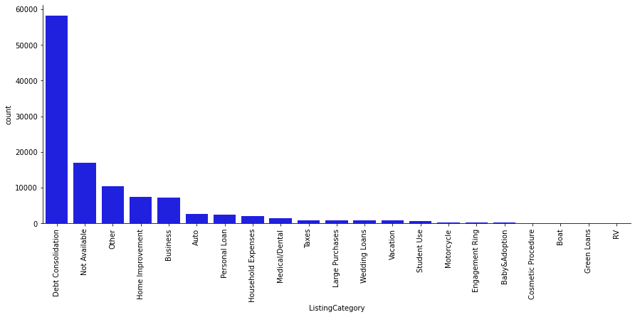

```python
# Making a plot of each listing category and the number of times they occured
sns.catplot(data = df, x="ListingCategory",kind="count", color ="blue",aspect = 2.5, order=list(df["ListingCategory"].value_counts().index))
plt.xticks(rotation=90)
plt.show()
plt.clf()
```

14.89% of the loans that had a listing category of "Not Avialable", a whooping 51.18% of the loans were listed for Debt Consolidation, 6.53% and 6.31% were listed as Home improvement and business respectively. The top 10 listings excluding the "Not available" category are

- Debt Consolidation
- Other
- Home Improvement
- Business
- Auto
- Personal Loan
- Household Expenses
- Medical/Dental
- Taxes
- Large Purchases

They account for 81.44% of the listed loans

### Which states had the highest loan listings

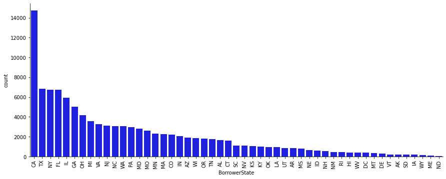

```python
# Making a plot of each Borrower state and the number of times they occured
sns.catplot(data = df, x="BorrowerState",kind="count", color ="blue",aspect = 2.5, order=list(df["BorrowerState"].value_counts().index))
plt.xticks(rotation=90)
plt.show()
plt.clf()
```

The state with the highest loan listings is Califonia accounting for 13.57% of the loan listings. The top 5 states based on number of loan listings are

- California(13.57%)
- Texas
- New york
- Florida
- Illinois

These states accounts for 37.75% of the loan listings

### Which EmploymentStatus had the highest loan listings

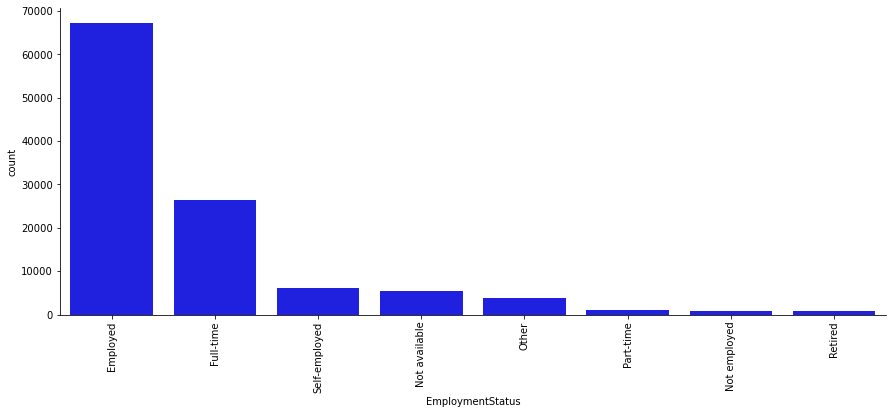

```python
# Making a plot of each Employment status and the number of times they occured
sns.catplot(data = df, x="EmploymentStatus",kind="count", color ="blue",aspect = 2.5, order=list(df["EmploymentStatus"].value_counts().index))
plt.xticks(rotation=90)
plt.show()
plt.clf()
```

60.28% of the Borrowers are Employed. This is followed by Full-time (23.6%), self-employed, Not available and Other. Partime, Not Employed and Retired only account for about 2.5% of the loans lsitings

### How is StatedMonthlyIncome of the borrower distributed?

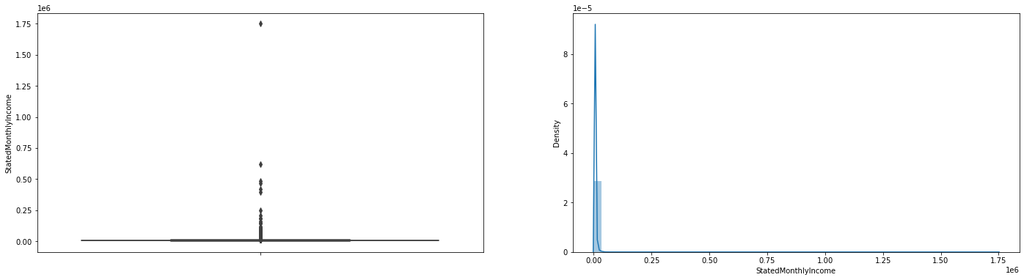

```python
# making a plot that shows the distribution of The StatedMonthlyIncome of the borrower
fig, ax = plt.subplots(1, 2, figsize = (24,6))
sns.boxplot(data=df, y="StatedMonthlyIncome", ax= ax[0])
sns.distplot(df["StatedMonthlyIncome"], ax = ax[1])
plt.show()
```

The distribution of the StatedMonthlyIncome is skewed to the right. 99.5% of its values are less than 25000. The values of the StatedMonthlyIncome ranges from 0 to 1750000. From the boxplot outliers were detected and the most obvious outlier is 1750000

### How is LoanOriginalAmount of the loan distributed?

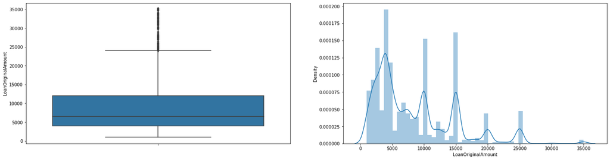

```python
# making a plot that shows the distribution of The LoanOriginalAmount of the loan

fig, ax = plt.subplots(1, 2, figsize = (24,6))
sns.boxplot(data=df, y="LoanOriginalAmount", ax= ax[0])
sns.distplot(df["LoanOriginalAmount"], ax = ax[1])
plt.show()
```

The distribution of the Loan original amount is multi modal, 95% of the loan original amount are less than or equal to 20000. The most occured loan amounts are usually multiples of 5000. only 5% of the loans are less than equal to 1500

### How is MonthlyLoanPayment of the loan distributed?

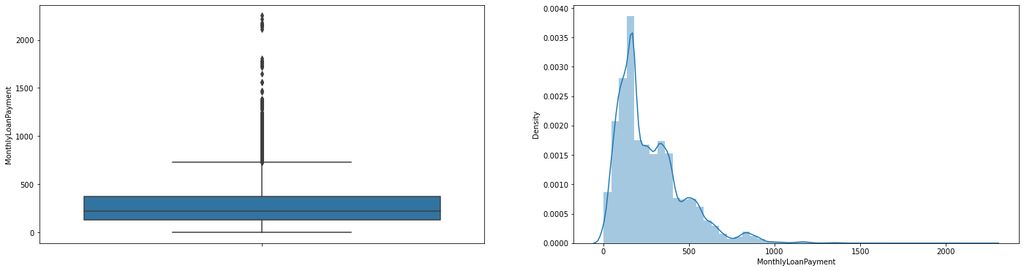

```python
# making a plot that shows the distribution of The MonthlyLoanPayment of the loan

fig, ax = plt.subplots(1, 2, figsize = (24,6))
sns.boxplot(data=df, y="MonthlyLoanPayment", ax= ax[0])
sns.distplot(df["MonthlyLoanPayment"], ax = ax[1])
plt.show()
```

### How is DebtToIncomeRatio of the borrower distributed?

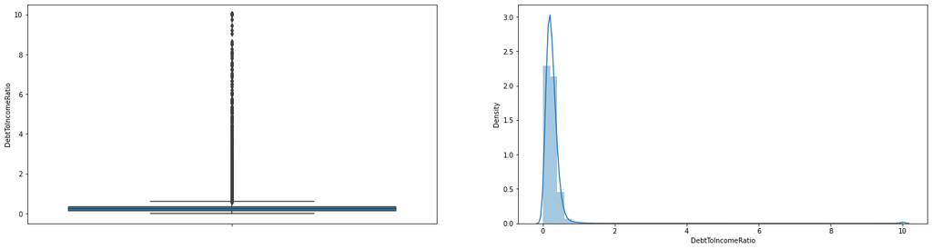

```python
# making a plot that shows the distribution of The DebtToIncomeRatio of the borrower

fig, ax = plt.subplots(1, 2, figsize = (24,6))
sns.boxplot(data=df, y="DebtToIncomeRatio", ax= ax[0])
sns.distplot(df["DebtToIncomeRatio"], ax = ax[1])
plt.show()
```

### Discuss the distribution(s) of your variable(s) of interest. Were there any unusual points? Did you need to perform any transformations?

- Term

77.04% of the loans have a term of 36 months, 21.54% have a term of 60 months with only 1.42% having a term of 12 months

- BorrowerRate

- ListingCategory

The ListingCategory column was created using the ListingCategory (numeric) column by mapping the number codes to theri corresponding terms. 14.89% of the loans that had a listing category of "Not Avialable", a whooping 51.18% of the loans were listed for Debt Consolidation, 6.53% and 6.31% were listed as Home improvement and business respectively.

- StatedMonthlyIncome

The distribution of the StatedMonthlyIncome is skewed to the right. 99.5% of its values are less than 25000. The values of the StatedMonthlyIncome ranges from 0 to 1750000. From the boxplot outliers were detected and the most obvious outlier is 1750000

- DebtToIncomeRatio

### Of the features you investigated, were there any unusual distributions? Did you perform any operations on the data to tidy, adjust, or change the form of the data? If so, why did you do this?

```python
# Excluding loans that are Current, Cancelled, and are FinalPaymentInProgress
df_filtered_1= df.query("LoanStatus == 'Completed' or LoanStatus == 'Past Due' or LoanStatus == 'Defaulted' or LoanStatus == 'Chargedoff'")
```

## Bivariate Exploration

> In this section, investigate relationships between pairs of variables in your data. Make sure the variables that you cover here have been introduced in some fashion in the previous section (univariate exploration).

### Is there a relationship between Loan term and loan status?

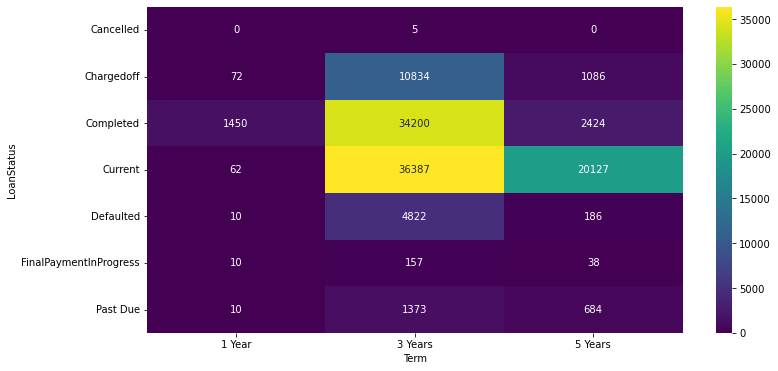

```python
# Defining a function that return the percetage of each of the Term that for a particular loan status
def percentage_fraction_1(LoanStatus, Term, df):
    y = df["Term"].value_counts(normalize = False)[Term]
    x = df[(df["Term"] == Term) & (df["LoanStatus"] == LoanStatus)].shape[0]
    return (x/y)*100

# making a plot that shows the number of loan listings for the different loan terms for each of the diffrent loan status

fig, ax = plt.subplots(figsize = (12,6))
ax = sns.heatmap(pd.crosstab(df.LoanStatus, df.Term), cmap="viridis", annot=True, fmt="g")
plt.show()
```

- 89.84% of the loans with a term of 1 year were completed, only 0.62 of the 1 year loans were defaulted and Past due.
- Only 38.96% of the 3 years loans were completed, 12.34% were charged off, 5.49% were defaulted, and 1.56% are Past due
- 9.88% of the 5 year loans were completed, 4.42% Charged off, 2.79% past due, only 0.78% were defaulted. 82% are current

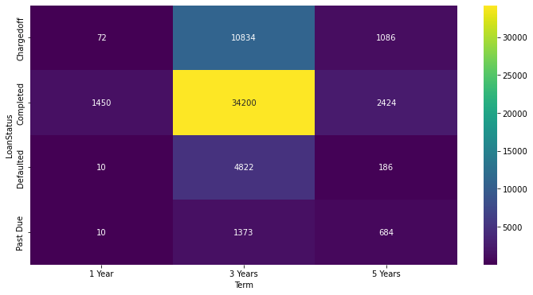

```python
# Excluding loans that are Current, Cancelled, and are FinalPaymentInProgress
# making a plot that shows the number of loan listings for the different loan terms for each of the diffrent loan status

fig, ax = plt.subplots(figsize = (12,6))
ax = sns.heatmap(pd.crosstab(df_filtered_1.LoanStatus, df_filtered_1.Term), cmap="viridis", annot=True, fmt="g")
plt.show()
```

Excluding loans that are Current, Cancelled, and are FinalPaymentInProgress

- 94.03% of the loans with a term of 1 year were completed, only 0.65 of the 1 year loans were defaulted and Past due, 4.67% were charged off,
- Only 66.76% of the 3 years loans were completed, 21.15% were charged off, 9.41% were defaulted, and 2.68% are Past due
- 55.34% of the 5 year loans were completed, 24.79% Charged off, 15.62% past due, only 4.25% were defaulted.

### Is there a relationship between Employment Status and loan status?

```
Full-time for Past Due 0.28368227585104683
Employed for Past Due 9.469696969696969
Not available for Past Due 0.0
Self-employed for Past Due 3.718328397499177
Part-time for Past Due 0.7518796992481203
Other for Past Due 12.882096069868995
Retired for Past Due 0.8534850640113799
Not employed for Past Due 4.429301533219761
```

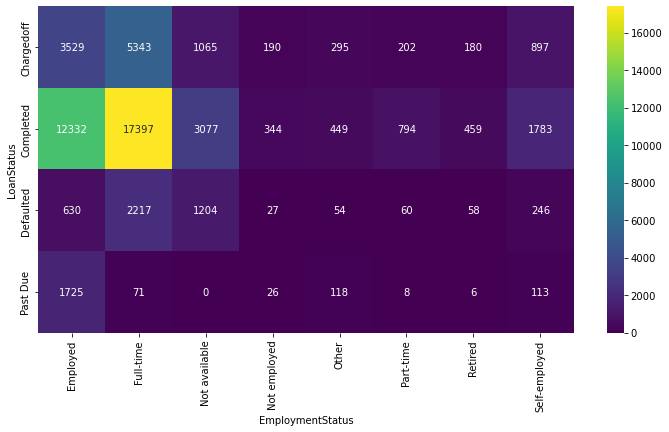

```python
# Defining a function that return the percetage of each of the Employment status that for a particular loan status
def percentage_fraction_2(LoanStatus, EmploymentStatuses, df):
    for EmploymentStatus in EmploymentStatuses:
        y = df["EmploymentStatus"].value_counts(normalize = False)[EmploymentStatus]
        x = df[(df["EmploymentStatus"] == EmploymentStatus) & (df["LoanStatus"] == LoanStatus)].shape[0]
        print(f"{EmploymentStatus} for {LoanStatus} {(x/y)*100}")

# Creating a list that contains the different Employment status
EmploymentStatuses = list(df_filtered_1.EmploymentStatus.value_counts().index)
percentage_fraction_2("Past Due", EmploymentStatuses, df_filtered_1)

# making a plot that shows the number of loan listings for the different EmploymentStatus for each of the diffrent loan status
fig, ax = plt.subplots(figsize = (12,6))
ax = sns.heatmap(pd.crosstab(df_filtered_1.LoanStatus, df_filtered_1.EmploymentStatus), cmap="viridis", annot=True, fmt="g")
plt.show()
```

Excluding loans that are Current, Cancelled, and are FinalPaymentInProgress

- For loans collected by Borrowers with employment status as Full-time, 69.51% were completed, 21.34% were charged off, 0.3% are past due, 8.9% are defaulted
- For loans collected by Borrowers with employment status as Employed, 67.69% were completed, 19.37% were charged off, 9.5% are past due, 3.5% are defaulted
- For loans collected by Borrowers with employment status as Not available, 57.55% were completed, 19.92% were charged off, 0% are past due, 22.5% are defaulted
- For loans collected by Borrowers with employment status as Self-employed, 58.67% were completed, 29.51% were charged off, 3.7% are past due, 8.1% are defaulted
- For loans collected by Borrowers with employment status as Part-time, 74.62% were completed, 18.98% were charged off, 0.8% are past due, 5.6% are defaulted
- For loans collected by Borrowers with employment status as Other, 49.01% were completed, 32.20% were charged off, 12.9% are past due, 5.9% are defaulted
- For loans collected by Borrowers with employment status as Retired, 65.29% were completed, 25.60% were charged off, 0.9% are past due ,8.3% are defaulted
- For loans collected by Borrowers with employment status as Not employed, 58.60% were completed, 32.36% were charged off, 4.4% are past due, 4.6% are defaulted

### Is there a relationship between Listing Category of the loan and loan status?

```python
Top_11_listing_categories = ["Not Available",
"Debt Consolidation",
"Other",
"Home Improvement",
"Business",
"Auto",
"Personal Loan",
"Household Expenses",
"Medical/Dental",
"Taxes",
"Large Purchases"]
```

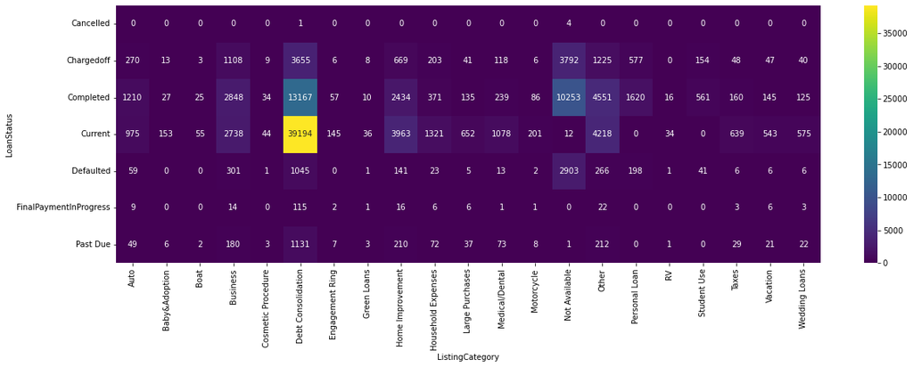

```python
# Defining a function that return the percetage of each of the Listing category that for a particular loan status
def percentage_fraction(LoanStatus, ListingCategories, df):
    for ListingCategory in ListingCategories:
        y = df["ListingCategory"].value_counts(normalize = False)[ListingCategory]
        x = df[(df["ListingCategory"] == ListingCategory) & (df["LoanStatus"] == LoanStatus)].shape[0]
        print(f"{ListingCategory} for {LoanStatus} {(x/y)*100}")

# making a plot that shows the number of loan listings for the different ListingCategory for each of the diffrent loan status
fig, ax = plt.subplots(figsize = (20,6))
ax = sns.heatmap(pd.crosstab(df.LoanStatus, df.ListingCategory), cmap="viridis", annot=True, fmt="g")
plt.show()
```

The top 10 listings excluding the "Not available" category are

- Debt Consolidation
- Other
- Home Improvement
- Business
- Auto
- Personal Loan
- Household Expenses
- Medical/Dental
- Taxes
- Large Purchases

They account for 81.44% of the listed loans.

- For loans collected for Debt consolidation, 22.58% were completed, 6.26% were charged off, 1.94% are past due, 1.79% are defaulted and 67.22% are current
- For loans collected for Other, 43.37% were completed, 11.67% were charged off, 2.02% are past due, 2.54% are defaulted and 40.19% are current
- For loans collected for Home Improvement, 32.75% were completed, 9% were charged off, 2.83% are past due, 1.90% are defaulted and 53.32% are current
- For loans collected for Business, 39.62% were completed, 15.41% were charged off, 2.50% are past due, 4.19% are defaulted and 38.09% are current
- For loans collected for Auto, 47.04% were completed, 10.5% were charged off, 1.91% are past due, 2.29% are defaulted and 37.91% are current
- For loans collected for Personal Loan, 67.64% were completed, 24.09% were charged off, 0% are past due, 8.27% are defaulted and 0% are current
- For loans collected for Household Expenses, 18.59% were completed, 10.17% were charged off, 4.80% are past due, 1.15% are defaulted and 66.18% are current
- For loans collected for Medical/Dental, 15.70% were completed, 7.75% were charged off, 3.61% are past due, 0.85% are defaulted and 70.83% are current
- For loans collected for Taxes, 18.08% were completed, 5.42% were charged off, 3.28% are past due, 0.68% are defaulted and 72.20% are current
- For loans collected for Large Purchases, 15.41% were completed, 4.68% were charged off, 4.22% are past due, 0.57% are defaulted and 74.43% are current

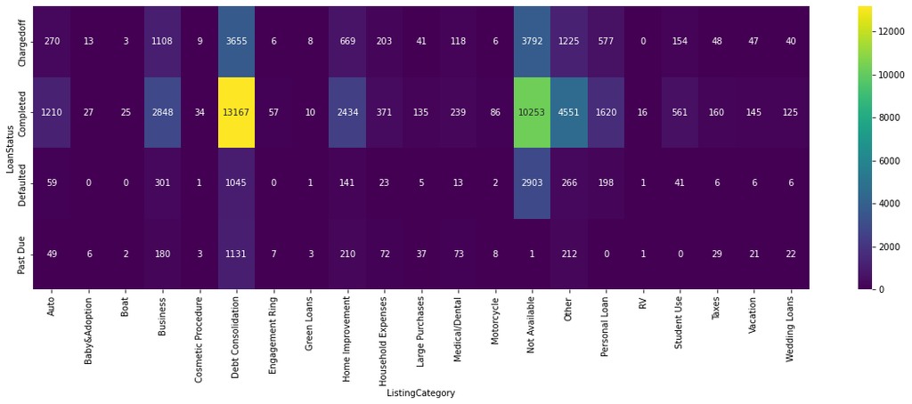

```python
# Excluding loans that are Current, Cancelled, and are FinalPaymentInProgress
# making a plot that shows the number of loan listings for the different ListingCategory for each of the diffrent loan status
fig, ax = plt.subplots(figsize = (20,6))
ax = sns.heatmap(pd.crosstab(df_filtered_1.LoanStatus, df_filtered_1.ListingCategory), cmap="viridis", annot=True, fmt="g")
plt.show()
```

They account for 98.31% of the listed loans.

### What is the distribution of Stated Monthly Income for the diffrent loan status?

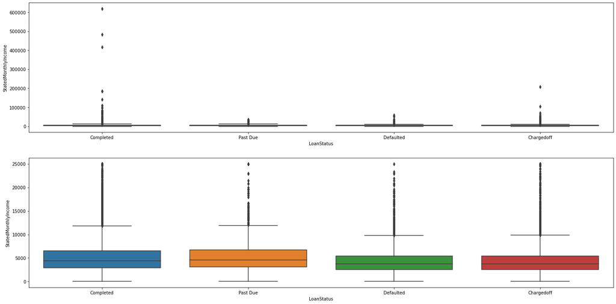

```python
# Excluding loans that are Current, Cancelled, and are FinalPaymentInProgress
fig, ax = plt.subplots(2,1,figsize = (24,12))
# Filtering out the top 0.5 percentile of the StatedMonthlyIncome
outlier_limit = df_filtered_1.StatedMonthlyIncome.quantile(0.995)
# making a plot that shows the distribution of The StatedMonthlyIncome of the borrower of each of the loan status
sns.boxplot(data=df_filtered_1, y="StatedMonthlyIncome", ax= ax[0], x="LoanStatus")
# making a plot that shows the distribution of The StatedMonthlyIncome of the borrower of each of the loan status, exluding the upper 0.5 percentile
sns.boxplot(data=df_filtered_1[df_filtered_1["StatedMonthlyIncome"] <= outlier_limit], y="StatedMonthlyIncome", ax= ax[1], x="LoanStatus")
plt.show()
```

### What is the distribution of Loan Original Amount for the diffrent loan status?

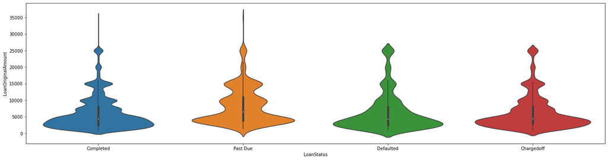

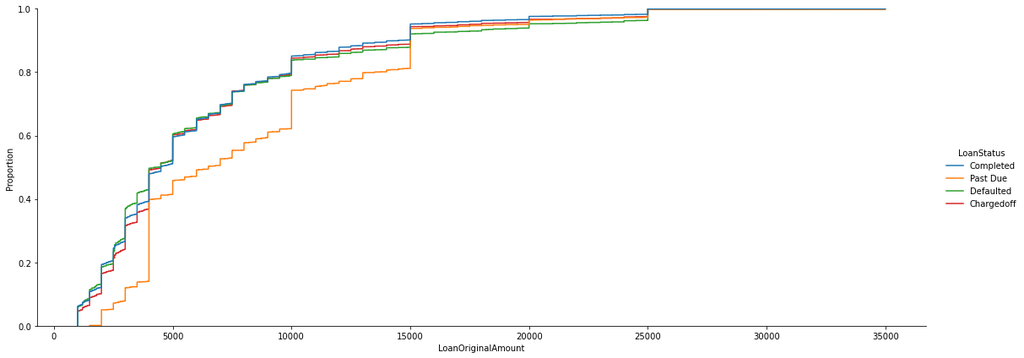

```python
# Excluding loans that are Current, Cancelled, and are FinalPaymentInProgress
# making a plot that shows the distribution of The Loan Original amount of the loan for each of the loan status
fig, ax = plt.subplots(figsize = (24,6))
sns.violinplot(data=df_filtered_1, y="LoanOriginalAmount", ax=ax, x="LoanStatus")
sns.displot(data=df_filtered_1, x="LoanOriginalAmount",height = 6, aspect=2.6, kind="ecdf", hue="LoanStatus")
plt.show()
```

For Defaulted loans, 55% and 95% are less than or equal to 5000 and 20000 respectively. 25% of the defaulted loans range from 8000 to 25000, 10% accounting for loans greater or equal to 15000.

For Chargedoff loans, 55% and 95% are less than or equal to 5000 and 17500 respectively. 25% of the Chargedoff loans range from 8000 to 25000, 10% accounting for loans greater or equal to 15000.

For Completed loans, 55% and 95% are less than or equal to 5000 and 15000 respectively. 25% of the Completed loans range from 8000 to 35000, 10% accounting for loans greater or equal to 145000.

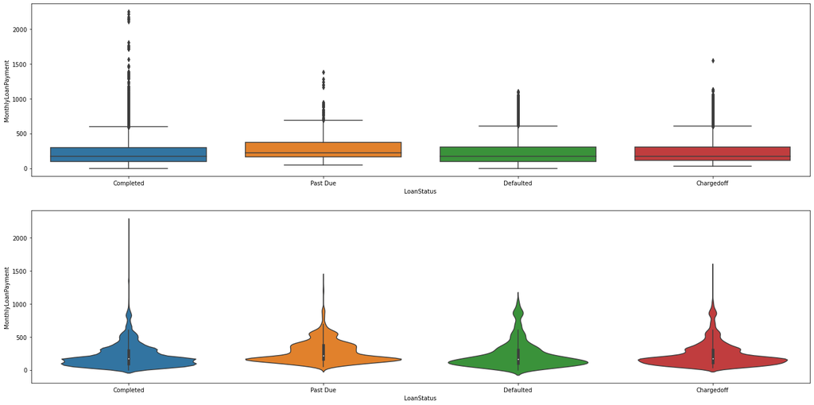

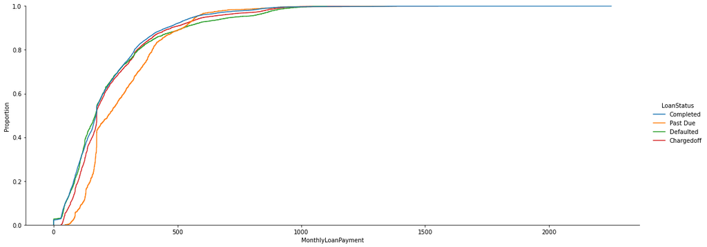

```python
# Excluding loans that are Current, Cancelled, and are FinalPaymentInProgress

# making a plot that shows the distribution of The MonthlyLoanPayment of the loan for each of the loan status
fig, ax = plt.subplots(2,1,figsize = (24,12))
sns.boxplot(data=df_filtered_1, y="MonthlyLoanPayment", ax= ax[0], x="LoanStatus")
sns.violinplot(data=df_filtered_1, y="MonthlyLoanPayment", ax= ax[1], x="LoanStatus")
sns.displot(data=df_filtered_1, x="MonthlyLoanPayment",height = 6, aspect=2.6, kind="ecdf", hue="LoanStatus")
plt.show()
```

From the Cummulative density plot, Loan listings that are past due have higher Monthly loan paymnet, followed by loans that were charged off. But a relatively larger proportion of Defaulted loans have Monthly loan paymnet greater than 500. This is closely followed by Past due and defaulted loans.

The plot of the full data using a violin plot and variable transformations reveals much more than the earlier box plots.

For Defaulted loans, 55% and 95% are less than 176 and 733 respectively. 25% of the Completed loans have monthly loan payments ranging from 303 to 1102, 10% accounting for loans greater or equal to 522.9650.

25% of the Past Due loans have monthly loan payments ranging from 374.240 to 1384.640, 10% accounting for loans greater or equal to 521.574.

For Chargedoff loans, 55% and 95% are less than 185 and 616 respectively. 25% of the Completed loans have monthly loan payments ranging from 308 to 1552, 10% accounting for loans greater or equal to 473.

```python
#df[df["LoanStatus"]=="Past Due"].MonthlyLoanPayment.quantile([0, 0.05,0.55, 0.75, 0.90, 0.95, 1])
```

### Is there a relationship between Stated Monthly Income and Debt-to-Income ratio?

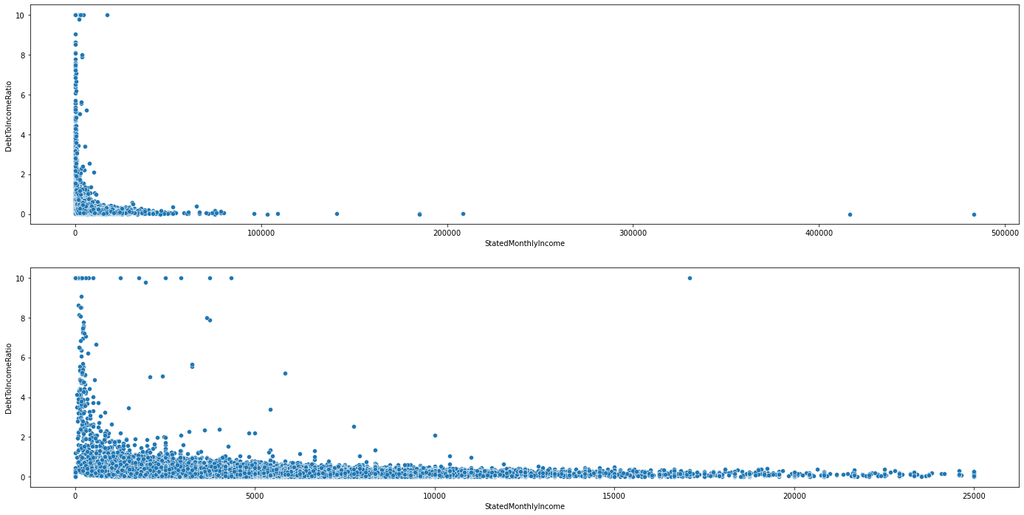

```
The correlation between Stated Monthly Income and Debt-to-Income ratio is -0.12045240414799115
```

```python
fig, ax = plt.subplots(2,1,figsize = (24,12))
# Plotting a scatter plot that shows the relationship between Stated Monthly Income and Debt-to-Income
sns.scatterplot(data=df_filtered_1[df_filtered_1["StatedMonthlyIncome"] <= outlier_limit], x="StatedMonthlyIncome", y="DebtToIncomeRatio", ax = ax[1])
sns.scatterplot(data=df_filtered_1, x="StatedMonthlyIncome", y="DebtToIncomeRatio", ax =ax[0])
plt.show()

# Printing the correlation between Stated Monthly Income and Debt-to-Income
print(f"The correlation between Stated Monthly Income and Debt-to-Income ratio is {df_filtered_1.StatedMonthlyIncome.corr(df_filtered_1.DebtToIncomeRatio)}")
```

From the scatterplpot and the correlation above, Higher values for Stated Monthly income have a lower debt-to-income ratio. There is weak negative correlation between these two features

### Is there a relationship between Stated Monthly Income and MonthlyLoanPayment?

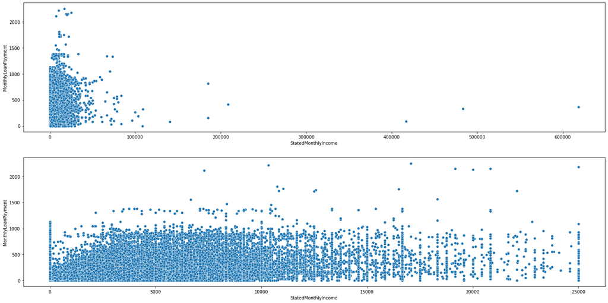

```
The correlation between Stated Monthly Income and Monthly Loan Payment is 0.20053885787348386
```

```python
fig, ax = plt.subplots(2,1,figsize = (24,12))

# Plotting a scatter plot that shows the relationship between Stated Monthly Income and Monthly Loan Payment

sns.scatterplot(data=df_filtered_1[df_filtered_1["StatedMonthlyIncome"] <= outlier_limit], x="StatedMonthlyIncome", y="MonthlyLoanPayment", ax = ax[1])
sns.scatterplot(data=df_filtered_1, x="StatedMonthlyIncome", y="MonthlyLoanPayment", ax =ax[0])
plt.show()


# Printing the correlation between Stated Monthly Income and Monthly Loan Payment
print(f"The correlation between Stated Monthly Income and Monthly Loan Payment is {df_filtered_1.StatedMonthlyIncome.corr(df_filtered_1.MonthlyLoanPayment)}")
```

From the scatterplpot and the correlation above, There is weak positive correlation between between Stated Monthly Income and Monthly Loan Payment

### Is there a relationship between Loan Original Amount and Debt-to-Income ratio?

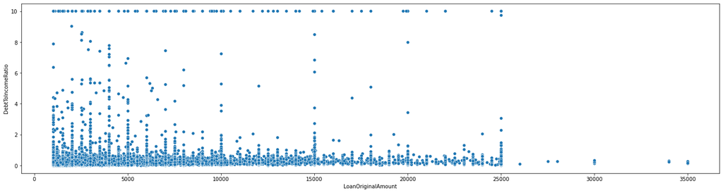

```
The correlation between Loan Original Amount and Debt-to-Income ratio is 0.04997454174953558
```

```python
fig, ax = plt.subplots(figsize = (24,6))
# Plotting a scatter plot that shows the relationship between  Loan Original Amount and Debt-to-Income ratio

sns.scatterplot(data=df_filtered_1, x="LoanOriginalAmount", y="DebtToIncomeRatio", ax =ax)
plt.show()


# Printing the correlation between  Loan Original Amount and Debt-to-Income ratio

print(f"The correlation between Loan Original Amount and Debt-to-Income ratio is {df_filtered_1.LoanOriginalAmount.corr(df_filtered_1.DebtToIncomeRatio)}")
```

From the scatter plot above, there is no linear correlation between Loan Original Amount and Debt-to-Income ratio

### Is there a relationship between Monthly Loan Payment and Debt-to-Income ratio?

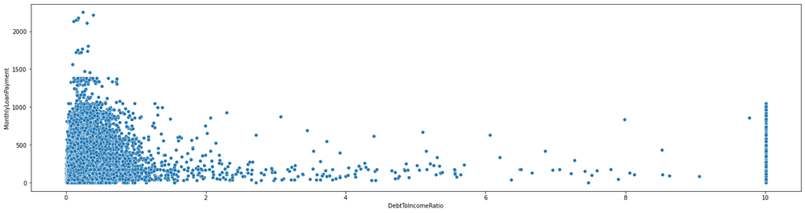

```
The correlation between Monthly Loan Payment and Debt-to-Income ratio is 0.058280100571623056
```

```python
# Plotting a scatter plot that shows the relationship between Monthly Loan Payment and Debt-to-Income ratio

fig, ax = plt.subplots(figsize = (24,6))
sns.scatterplot(data=df_filtered_1, y="MonthlyLoanPayment", x="DebtToIncomeRatio", ax =ax)
plt.show()

#Printing the correlation between Monthly Loan Payment and Debt-to-Income ratio

print(f"The correlation between Monthly Loan Payment and Debt-to-Income ratio is {df_filtered_1.DebtToIncomeRatio.corr(df_filtered_1.MonthlyLoanPayment)}")
```

From the scatter plot above, there is no linear correlation between Monthly Loan Payment and Debt-to-Income, but lower values of Debt to income ratio had higher values for monthly loan payment.

### Is there a relationship between Loan Original Amount and Monthly Loan Payment?

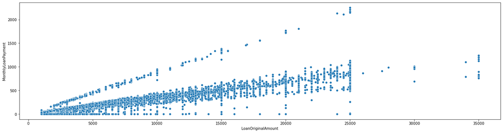

```
The correlation between Loan Original Amoun and Monthly Loan Payment is 0.9308817176532008
```

```python
# Plotting a scatter plot that shows the relationship between Loan Original Amoun and Monthly Loan Payment

fig, ax = plt.subplots(figsize = (24,6))
sns.scatterplot(data=df_filtered_1, x="LoanOriginalAmount", y="MonthlyLoanPayment", ax =ax)
plt.show()

#Printing the correlation between Loan Original Amoun and Monthly Loan Payment

print(f"The correlation between Loan Original Amoun and Monthly Loan Payment is {df_filtered_1.LoanOriginalAmount.corr(df_filtered_1.MonthlyLoanPayment)}")
```

From the scatter plot above, there is a strong linear correlation between Monthly Loan Payment and Loan Original Amount, higher values of Loan Original Amount had higher values for monthly loan payment and vice versa.

### Is there a relationship between Loan Original Amount and Stated Monthly Income?

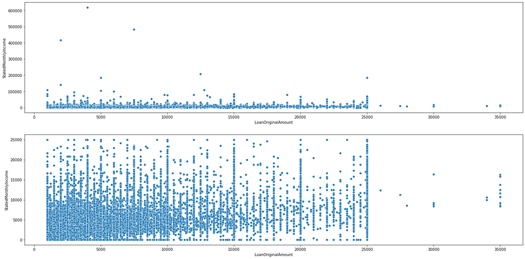

```
The correlation between Stated Monthly Income and Loan Original Amoun is 0.20125946794116203
```

```python
# Plotting a scatter plot that shows the relationship between SStated Monthly Income and Loan Original Amount
fig, ax = plt.subplots(2,1,figsize = (24,12))
sns.scatterplot(data=df_filtered_1[df_filtered_1["StatedMonthlyIncome"] <= outlier_limit], x="LoanOriginalAmount", y="StatedMonthlyIncome", ax = ax[1])
sns.scatterplot(data=df_filtered_1, x="LoanOriginalAmount", y="StatedMonthlyIncome", ax =ax[0])
plt.show()

#Printing the correlation between Stated Monthly Income and Loan Original Amount

print(f"The correlation between Stated Monthly Income and Loan Original Amoun is {df.LoanOriginalAmount.corr(df.StatedMonthlyIncome)}")
```

From the scatter plot above, there is a weak positive linear correlation between Stated Monthly Income and Loan Original Amount

### Talk about some of the relationships you observed in this part of the investigation. How did the feature(s) of interest vary with other features in the dataset?

**IS THERE A RELATIONSHIP BETWEEN THE TERM OF THE LOAN AND THE STATUS OF THE LOAN?**

- 89.84% of the loans with a term of 1 year were completed, only 0.62 of the 1 year loans were defaulted and Past due.
- Only 38.96% of the 3 years loans were completed, 12.34% were charged off, 5.49% were defaulted, and 1.56% are Past due
- 9.88% of the 5 year loans were completed, 4.42% Charged off, 2.79% past due, only 0.78 person were defaulted. 82% are current

**Is there a relationship between Listing Category of the loan and loan status?**

The top 10 listing category excluding the "Not available" category are

- Debt Consolidation
- Other
- Home Improvement
- Business
- Auto
- Personal Loan
- Household Expenses
- Medical/Dental
- Taxes
- Large Purchases

They account for 81.44% of the listed loans.

- For loans collected for Debt consolidation, 22.58% were completed, 6.26% were charged off, 1.94% are past due, 1.79% are defaulted and 67.22% are current
- For loans collected for Other, 43.37% were completed, 11.67% were charged off, 2.02% are past due, 2.54% are defaulted and 40.19% are current
- For loans collected for Home Improvement, 32.75% were completed, 9% were charged off, 2.83% are past due, 1.90% are defaulted and 53.32% are current
- For loans collected for Business, 39.62% were completed, 15.41% were charged off, 2.50% are past due, 4.19% are defaulted and 38.09% are current
- For loans collected for Auto, 47.04% were completed, 10.5% were charged off, 1.91% are past due, 2.29% are defaulted and 37.91% are current
- For loans collected for Personal Loan, 67.64% were completed, 24.09% were charged off, 0% are past due, 8.27% are defaulted and 0% are current
- For loans collected for Household Expenses, 18.59% were completed, 10.17% were charged off, 4.80% are past due, 1.15% are defaulted and 66.18% are current
- For loans collected for Medical/Dental, 15.70% were completed, 7.75% were charged off, 3.61% are past due, 0.85% are defaulted and 70.83% are current
- For loans collected for Taxes, 18.08% were completed, 5.42% were charged off, 3.28% are past due, 0.68% are defaulted and 72.20% are current
- For loans collected for Large Purchases, 15.41% were completed, 4.68% were charged off, 4.22% are past due, 0.57% are defaulted and 74.43% are current

Excluding loans that are Current, Cancelled, and are FinalPaymentInProgress and focusing on the top 11 Listingcategories which account for 98.31% of the listed loans.

**What is the distribution of Stated Monthly Income for the diffrent loan status?**

**What is the distribution of Loan Original Amount for the diffrent loan status?**

For Defaulted loans, 55% and 95% are less than or equal to 5000 and 20000 respectively. 25% of the defaulted loans range from 8000 to 25000, 10% accounting for loans greater or equal to 15000.

For Chargedoff loans, 55% and 95% are less than or equal to 5000 and 17500 respectively. 25% of the Chargedoff loans range from 8000 to 25000, 10% accounting for loans greater or equal to 15000.

For Completed loans, 55% and 95% are less than or equal to 5000 and 15000 respectively. 25% of the Completed loans range from 8000 to 35000, 10% accounting for loans greater or equal to 145000.

### Did you observe any interesting relationships between the other features (not the main feature(s) of interest)?

**Is there a relationship between Stated Monthly Income and Debt-to-Income ratio?**

From the scatterplpot and the correlation above, Higher values for Stated Monthly income have a lower debt-to-income ratio. There is weak negative correlation between these two features

**Is there a relationship between Loan Original Amount and Debt-to-Income ratio?**

there is no linear correlation between Loan Original Amount and Debt-to-Income ratio

**Is there a relationship between Loan Original Amount and Stated Monthly Income?**

From the scatterplpot and the correlation above, Higher values for Stated Monthly income have a Loan Original Amount. There is weak positive correlation between these two features

### Were there any interesting or surprising interactions between features?

- One would assume that loans with longer terms have a higher completion rates. But the reverse has been the case. 5 years and 3 years loans have the lowest completion rate, and the highest default and Chargedoff rate.

## Multivariate Exploration

### Is there a relationship between MonthlyLoanPayment, Loan Status and LoanOriginalAmount?

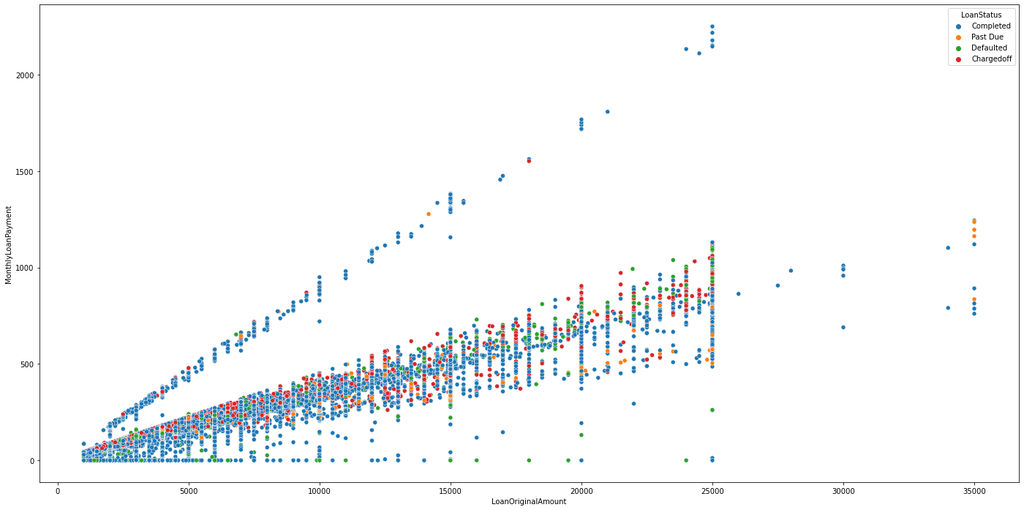

```
The correlation between Loan Original Amoun and Monthly Loan Payment is 0.9319836797293982
```

```python
# Plotting a scatter plot that shows the relationship between Loan Original Amount, Monthly Loan Payment and the loan status.
fig,ax = plt.subplots(figsize = (24,12))
sns.scatterplot(data=df_filtered_1, x="LoanOriginalAmount", y="MonthlyLoanPayment",hue="LoanStatus", ax =ax)
plt.show()

#Printing the correlation between Loan Original Amount and Monthly Loan Payment
print(f"The correlation between Loan Original Amoun and Monthly Loan Payment is {df.LoanOriginalAmount.corr(df.MonthlyLoanPayment)}")
```

### Is there a relationship between DebtToIncomeRatio, Loan Status, Term and Stated Monthly Income?

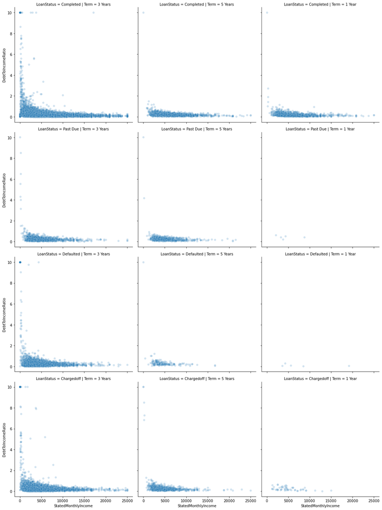

```python
# Plotting a scatter plot that shows the relationship between StatedMonthlyIncome and DebtToIncomeRatio
#for the various loan terms and each of the loan status
sns.relplot(data=df_filtered_1[df_filtered_1["StatedMonthlyIncome"] <= outlier_limit], x="StatedMonthlyIncome",col="Term",
                y="DebtToIncomeRatio",row = "LoanStatus",alpha=0.2)
```

### Is there a relationship between LoanOriginalAmount, Loan Status and Stated Monthly Income?

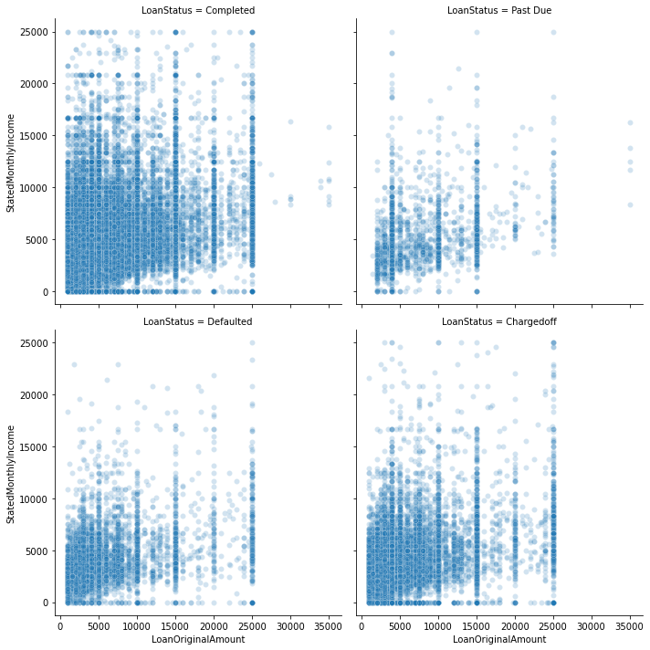

```python
# Plotting a scatter plot that shows the relationship between StatedMonthlyIncome and LoanOriginalAmount for the various the loan status
sns.relplot(data=df_filtered_1[df_filtered_1["StatedMonthlyIncome"] <= outlier_limit], y="StatedMonthlyIncome",
                x="LoanOriginalAmount",col = "LoanStatus",alpha=0.2, col_wrap = 2)
```

Defaulted and charged off loans have lower stated monthly income and relatively a larger pecentage of low Loan original amount as opposed to Completed and Current loans

### Talk about some of the relationships you observed in this part of the investigation. Were there features that strengthened each other in terms of looking at your feature(s) of interest?

**Is there a relationship between MonthlyLoanPayment, Loan Status and LoanOriginalAmount?**

**Is there a relationship between DebtToIncomeRatio, Loan Status, Term and Stated Monthly Income?**

**Is there a relationship between LoanOriginalAmount, Loan Status and Stated Monthly Income?**

Defaulted and charged off loans have lower stated monthly income and relatively a larger pecentage of low Loan original amount as opposed to Completed and Current loans

### Were there any interesting or surprising interactions between features?

- Loan listings that are past due have higher Monthly loan paymnet, followed by loans that were charged off.

## Conclusions

Of 113,937 loan listings, 49.65% are current, 33.42% of the loans are completed, 10.53% and 4.40% are chargedoff and defaulted respectively with 1.81% percent past due with less than 0.2% accounting for Cancelled and Final Payment in progress listings. Giving out loans could be for a lot of different reasons - improving the socioeconomic life of the borrower, saving the life of the borrower, imporiving the economy of a state by funding business and investments, but sometimes, or rather most of the times, its to make profit and/or a combo of making profits and other reasons.

*The objective of this analysis is to identify and understand patterns responsible for Defaulted, Chargedoff, and past due loans and to improve the percentage of completed loans. To make data driven decisions on whether a loan should be approved.*

A loan listing could either be a 12-month loans, or a 36-month or 60-month loan. 77.04% of the loan listings have a term of 36 months, with 60-months and 12-months loans accounting for 21.54% and 1.42% of the loan listings.

each loan listing has a corresponding listing category, which gives an idea about "What is the loan for". The data had 21 listing categories, but the top 11 most occured categores which accounts for 96.33% of the loan listings. A whooping 51.18% of the loans are for Debt consolidation. The top 11 categories are

- Debt Consolidation
- Not Available
- Other
- Home Improvement
- Business
- Auto
- Personal Loan
- Household Expenses
- Medical/Dental
- Taxes
- Large Purchases

37.75% of the borrowers are from California(13.57%), Texas, New york, Florida and Illinois. These are the top 5(out of 51) states with the highest loan listings.

60.28% of the Borrowers are Employed. This is followed by Full-time (23.6%), self-employed, Not available and Other. Partime, Not Employed and Retired only account for about 2.5% of the loans lsitings

The Original Loan amounts are majorly multiple of 5000s ranging from 5000 - 35000, But 95% of the original loan amount are less than or equal to 20,000. The stated monthly income has an outlier, 1750000 and 99.5% of the stated monthly income are less than or equal to 25000, which is 10000 less the maximum Original loan amount. 95% of the Monthly loan payments are less than or equal to 634.91, which is more than triple the mode and median of the monthly loan payments. The 95th percentile of monthly loan payments is greater than 1/36 of the 95th percentile of the Original loan amount. *This implies, that a 25000 loan would be completed in less than or 36 months if a borrower makes a monthly payment greater than or equal to 556 which is less than the 92nd percentile of the monthly loan paymets.*

The distribution of the DebtToIncomeRatio is skewed to the right. 99% of the borrowers have a DebtToIncomeRatio less than 0.86 with only 5% of the borrowers having a DebtToIncomeRatio less than 0.06.

Inline with the objective of the analysis - identifying and understanding patterns responsible for Defaulted, Chargedoff, and past due loans and to improve the percentage of completed loans in To make data driven decisions on whether a loan should be approved, loans that are Current, Cancelled, and FinalPaymentInProgress were exluded or filtered out.

1 year loans are good for business, but they only account for 1.42% of the loan listing. They have a whooping 94% completion rate. The Chargedoff 1 year loans have low stated monthly income. Only 66.8% of the 3 year loans were completed. Not high enough. 21.2% and 9.4% of the 3 year loans were Chargedoff and defaulted respectively. Now that's bad for business. but it doesn't just end there. 5 year loans are just as bad or worse. With a completion rate of only 55.3%. 24.8% and 15.6% of these loans are charged off and Past due resepctively. 4.3% of the loans are also defaulted. Is there something responsible for thes. Is there someting the can be done to turn this over?

Breaking it down. The followig categories that the least completion rate in ascending order:

- Medical/Dental
- Household Expenses
- Not available
- Large Purchases
- Business
- Taxes

The followig categories have the highest Chargeoff percentage in descending order:

- Household Expenses
- Medical/Dental
- Business
- Personal Loan
- Not available
- Taxes

There is a strong linear correlation between Monthly Loan Payment and Loan Original Amount, higher values of Loan Original Amount had higher values for monthly loan payment and vice versa.